# An illustration of the sensitivity of arithmetic mean

#### *CIE 600: Environmental Data Analysis: Scripting Assignment 1*

#### *Jan 26, 2017*

This is an R notebook I made using R studio to provide a graphical illustration of how mean and median values change using a simple dataset. If you have never used R notebooks before there is a good introduction [here](http://rmarkdown.rstudio.com/r_notebooks.html) and you might also find this [reference guide](https://www.rstudio.com/wp-content/uploads/2015/03/rmarkdown-reference.pdf) and this [intro](https://gist.github.com/jeromyanglim/2716336) for R Markdown useful.

## Initial data

I’m starting with a very simple dataset I’m calling *data*. I generate *data* as a series from 0 to 50 and then I calculate the mean and median values.

```r
data=seq(0, 50,5) #The seq function is creating a series from 0 to 50 with increments of 5
xbar=mean(data) #Calculating the arithmetic mean
q50=median(data) #Calcualting the median
```

Next I plot the points in *data* and the mean and median

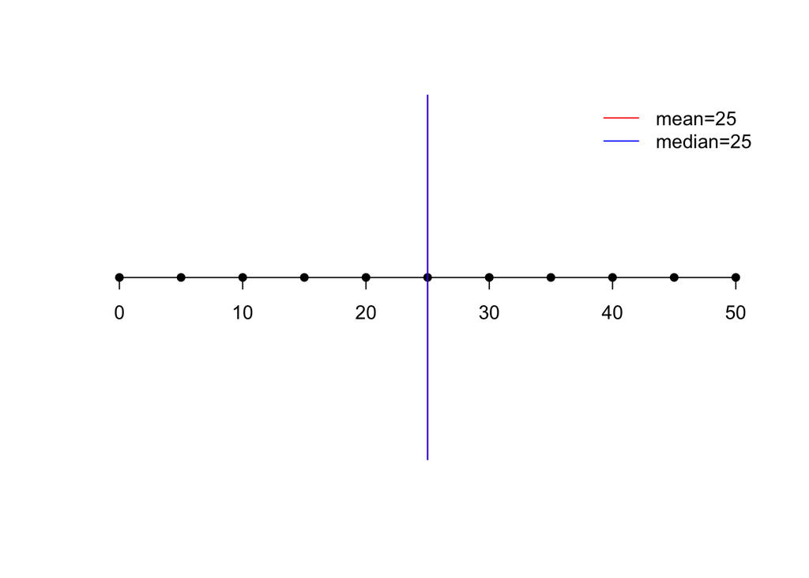

```r
#Check out ?plot to see all of the options for this function
plot(data, rep(0, length(data)), axes=FALSE, xlim=c(0,50), type="p",xlab="",ylab="", pch=16)

#In my initail plot I turned the axes of so now I need to draw just the x axis onto my plot
axis(1,pos=0)

 #adding vertical lines for the mean and median
abline(v=xbar, lty=1, col='red')
abline(v=q50, lty=1, col='blue')

#adding a legend
legend('topright', legend=c(paste("mean=", xbar, sep=""), paste("median=",q50, sep="")), lty=c(1,1), col=c('red', 'blue'), bty='n')
```

You can see here that the mean and the median are exactly the same, they are both 25.

## Initial data plus 5

Now I will take the initial dataset and add 5 to every value

```r
#These are the new values
dataN1=data+5 #note that when you add a value to a vector R, will automatically apply that to every element of the vector
xbarN1=mean(dataN1)
q50N1=median(dataN1)
```

This is what the new outputs look like:

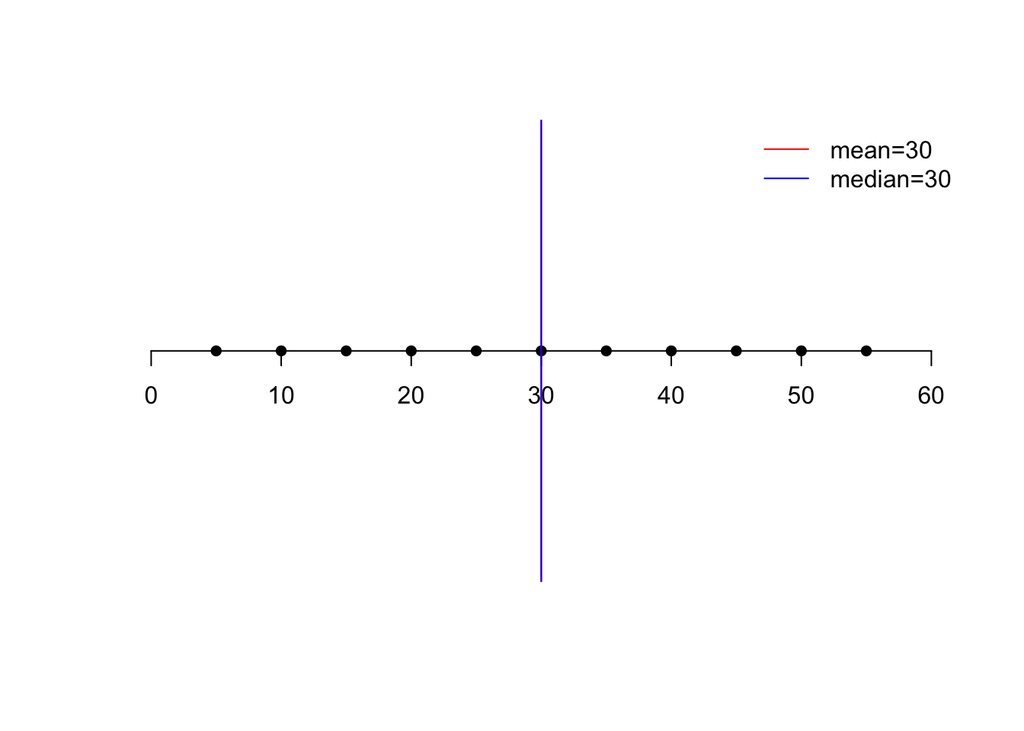

```r
plot(dataN1, rep(0, length(dataN1)), axes=FALSE, xlim=c(0,60), type="p",xlab="",ylab="", pch=16)
axis(1,pos=0)
abline(v=xbarN1, lty=1, col='red')
abline(v=q50N1, lty=1, col='blue')
legend('topright', legend=c(paste("mean=", xbarN1, sep=""), paste("median=",q50N1, sep="")), lty=c(1,1), col=c('red', 'blue'), bty='n')
```

The mean and the median are still the same but they have both been shifted 5 from the original values.

## Initial data multipled by 5

Next I will scale the initial dataset by 5

```r
#These are the new values
dataN2=data*5
xbarN2=mean(dataN2)
q50N2=median(dataN2)
```

This is what the new outputs look like:

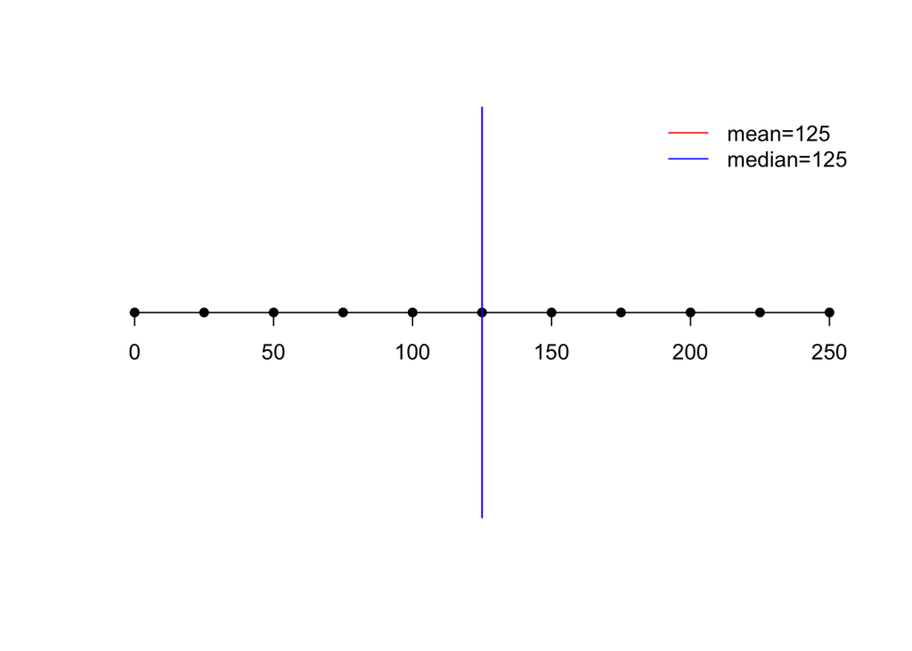

```r
plot(dataN2, rep(0, length(dataN2)), axes=FALSE, xlim=c(0,250), type="p",xlab="",ylab="", pch=16)
axis(1,pos=0)
abline(v=xbarN2, lty=1, col='red')
abline(v=q50N2, lty=1, col='blue')
legend('topright', legend=c(paste("mean=", xbarN2, sep=""), paste("median=",q50N2, sep="")), lty=c(1,1), col=c('red', 'blue'), bty='n')
```

Once again the mean and median are the same and now they are scaled by 5 from the original values.

## Initial data squared

Now we will try something more complicated and square *data*.

```r
#These are the new values
dataN3=data^2
xbarN3=mean(dataN3)
q50N3=median(dataN3)
```

This is what the new outputs look like:

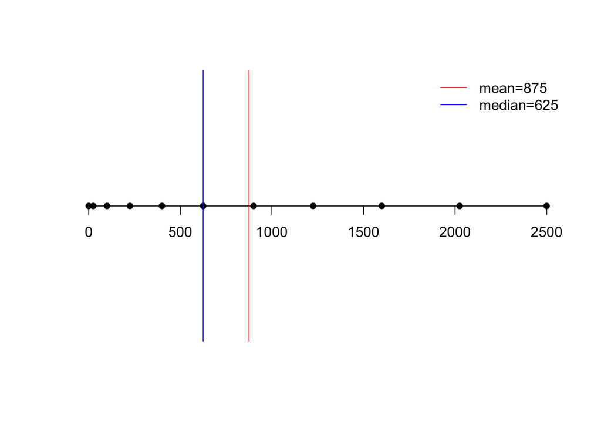

```r
plot(dataN3, rep(0, length(dataN3)), axes=FALSE, xlim=c(0,2500), type="p",xlab="",ylab="", pch=16)
axis(1,pos=0)
abline(v=xbarN3, lty=1, col='red')
abline(v=q50N3, lty=1, col='blue')
legend('topright', legend=c(paste("mean=", xbarN3, sep=""), paste("median=",q50N3, sep="")), lty=c(1,1), col=c('red', 'blue'), bty='n')
```

Now the mean and median are different. This is because we have created greater intervals between the larger values in the dataset than the small ones by squaring. Note that the mean has been pulled farther to the large values than the median.

## Initial data plus one outlier

What happens if instead of doing something to all the points in the *data*, I just add a single outlier?

```r
#These are the new values
dataN4=c(data, 150)
xbarN4=round(mean(dataN4),1) #this time I'm rounding the mean so its nicer for reporting
q50N4=median(dataN4)
```

This is what the new outputs look like:

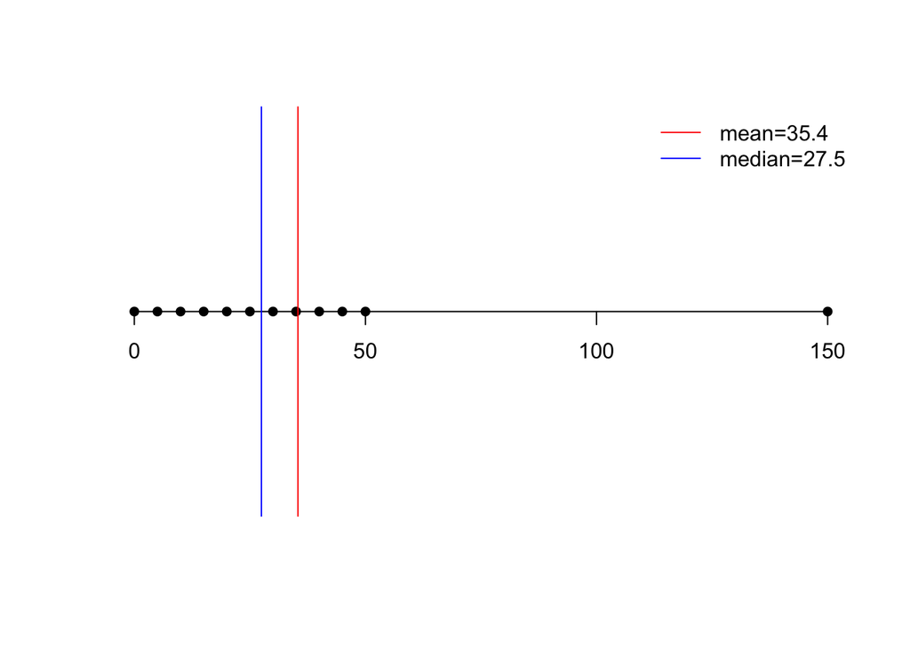

```r
plot(dataN4, rep(0, length(dataN4)), axes=FALSE, xlim=c(0,150), type="p",xlab="",ylab="", pch=16)
axis(1,pos=0)
abline(v=xbarN4, lty=1, col='red')
abline(v=q50N4, lty=1, col='blue')
legend('topright', legend=c(paste("mean=", xbarN4, sep=""), paste("median=",q50N4, sep="")), lty=c(1,1), col=c('red', 'blue'), bty='n')
```

Here too the mean and median are different from each other and from the initial mean and median values of 25. The mean has been shifted more than the median because it is a metric which is more sensitive to outliers.

## Summary

Okay now we can put it all together.

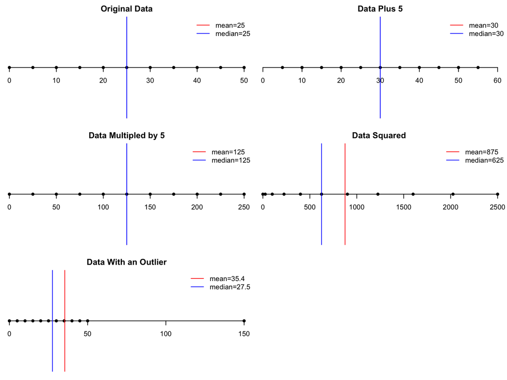

```r
par(mfrow=c(3,2), mar=c(1,0,2,0)) #setting up a multi-panel figure

#Original Data
plot(data, rep(0, length(data)), axes=FALSE, xlim=c(0,50), type="p",xlab="",ylab="", pch=16, main="Original Data")
axis(1,pos=0)
abline(v=xbar, lty=1, col='red')
abline(v=q50, lty=1, col='blue')
legend('topright', legend=c(paste("mean=", xbar, sep=""), paste("median=",q50, sep="")), lty=c(1,1), col=c('red', 'blue'), bty='n')

#Data +5
plot(dataN1, rep(0, length(dataN1)), axes=FALSE, xlim=c(0,60), type="p",xlab="",ylab="", pch=16, main="Data Plus 5")
axis(1,pos=0)
abline(v=xbarN1, lty=1, col='red')
abline(v=q50N1, lty=1, col='blue')
legend('topright', legend=c(paste("mean=", xbarN1, sep=""), paste("median=",q50N1, sep="")), lty=c(1,1), col=c('red', 'blue'), bty='n')

#Data *5
plot(dataN2, rep(0, length(dataN2)), axes=FALSE, xlim=c(0,250), type="p",xlab="",ylab="", pch=16, main="Data Multipled by 5")
axis(1,pos=0)
abline(v=xbarN2, lty=1, col='red')
abline(v=q50N2, lty=1, col='blue')
legend('topright', legend=c(paste("mean=", xbarN2, sep=""), paste("median=",q50N2, sep="")), lty=c(1,1), col=c('red', 'blue'), bty='n')

#Data ^2
plot(dataN3, rep(0, length(dataN3)), axes=FALSE, xlim=c(0,2500), type="p",xlab="",ylab="", pch=16, main="Data Squared ")
axis(1,pos=0)
abline(v=xbarN3, lty=1, col='red')
abline(v=q50N3, lty=1, col='blue')
legend('topright', legend=c(paste("mean=", xbarN3, sep=""), paste("median=",q50N3, sep="")), lty=c(1,1), col=c('red', 'blue'), bty='n')

#Data with and outlier
plot(dataN4, rep(0, length(dataN4)), axes=FALSE, xlim=c(0,150), type="p",xlab="",ylab="", pch=16, main="Data With an Outlier")
axis(1,pos=0)
abline(v=xbarN4, lty=1, col='red')
abline(v=q50N4, lty=1, col='blue')
legend('topright', legend=c(paste("mean=", xbarN4, sep=""), paste("median=",q50N4, sep="")), lty=c(1,1), col=c('red', 'blue'), bty='n')
```

From this you can see that shifting or scaling a dataset will shift and scale both the mean and the median by whatever factor you have applied. But applying a power transform or adding outliers to the dataset will change the symmetry and will impact the mean and the median differently.